# LAB 6:계절성이 있는 자료에서의 Seasonal ARIMA 모형 적합

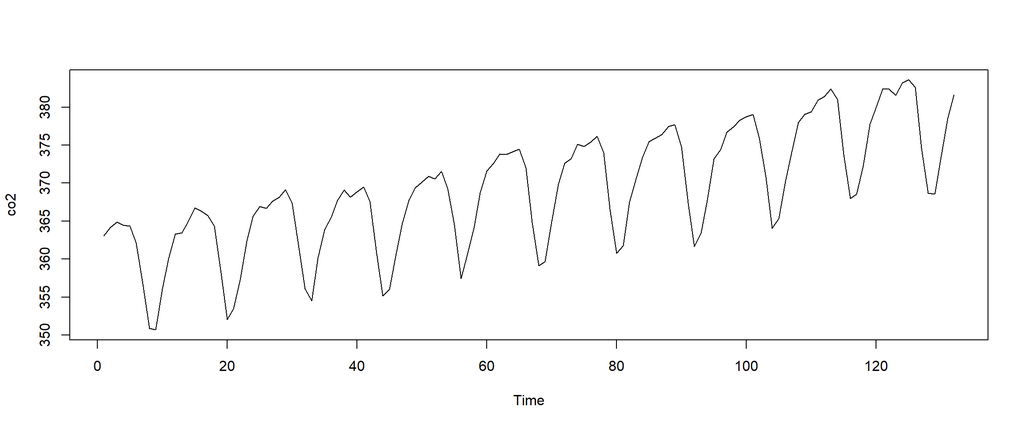

```r
> library(TSA)
> data(co2)
> co2<-ts(co2)
```

뚜렷한 계절성과 선형추세가 관찰됨. 분산은 어느 정도 안정되어 보임.  
계절성이 뚜렷하여 sample 자기상관계수 값은 주기의 배수 부분에서 천천히 감소할 것으로 예상됨($\Longrightarrow$계절차분 필요). 또한 선형추세가 있기 때문에 계절차분후에는 기대값이 0이 아닌 시계열형태가 될 것으로 예상됨.

### 모형식별

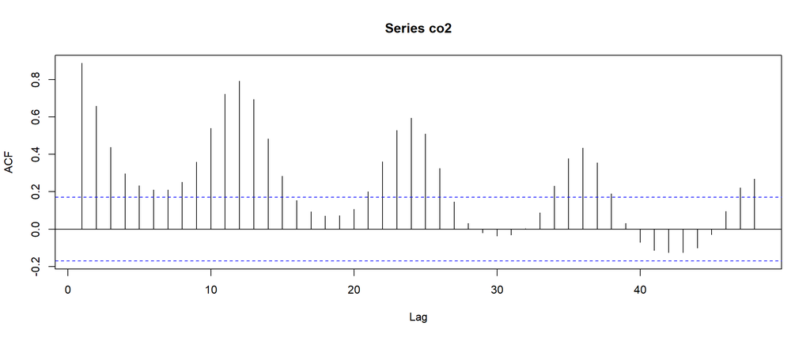

```r
> acf(co2,lag.max=48)
```

예상했던 바와 같이, lag 1년, 2년, 3년에서의 sample 자기상관계수 값이 천천히(?) 감소함.

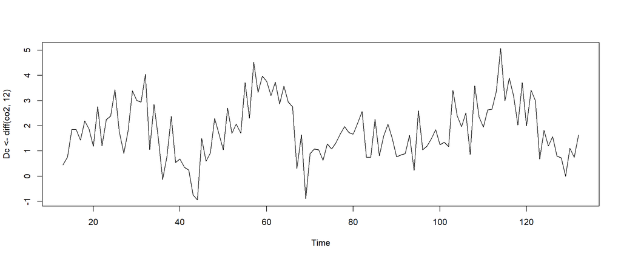

```r
> ts.plot(Dc<-diff(co2, 12))
```

계절 차분된 자료는 평균이 0이 아닌 시계열로 보임.

정상 시계열 ? 확률적 추세를 보이는 시계열?

SACF와 SPACF 등으로 판단하면

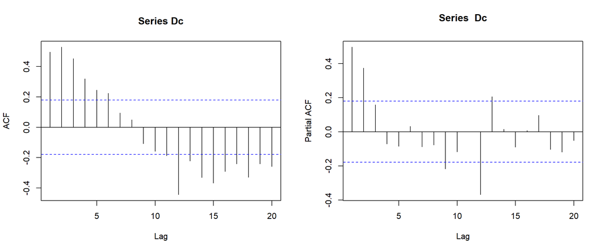

```r
> layout(t(1:2))
> acf(Dc); pacf(Dc)
```

```r
> #library(aTSA)
```

ARMA모형의 ACF는 지수적으로 감소함. 위 Sample ACF는 지수적으로 감소하는 형태라고 볼 수 있는가??

위 자료는 선형으로 감소하는 형태로 판단되므로, 확률적 추세로 보고 추가적으로 차분 수행

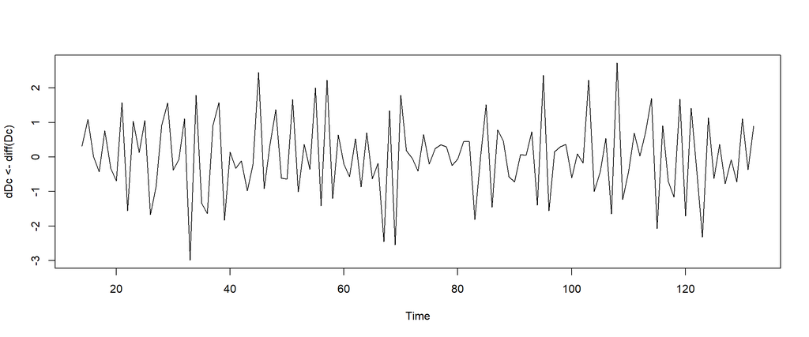

```r
> ts.plot(dDc<-diff(Dc))
```

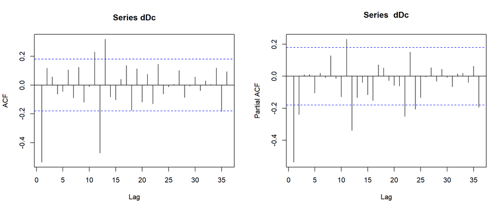

```r
> layout(t(1:2))
> acf(dDc, lag.max = 36); pacf(dDc, lag.max = 36)
```

Lag 12에서 sample 자기상관계수와 Lag 12,24 등에서 sample 부분자기상관계수 값들이 유의하면서 빠르게 감소하고, 인접한 값들 사이의 관계또 존재하고 있으므로, 위 $\{\bigtriangledown\bigtriangledown^{12} X_t\}$는 다음의 승법계절 ARIMA모형을 적합할 수 있는 정상시계열자료로 판단됨.
$$\{\bigtriangledown\bigtriangledown^{12}X_t\} \sim ARIMA(p,0,q)(P,0,Q)_{12}$$
$$\Longleftrightarrow \{X_t\} \sim ARIMA(p,1,q)(P,1,Q)_{12}$$
차분된 자료 $\{\bigtriangledown\bigtriangledown^{12} X_t\}$를 이용하여 차수 p,q,P,Q를 결정(여기서는 AIC를 기준으로 선택하고자 함).

```r
> library(forecast)
> aic<-1000
> for(p in 0:2) for(q in 0:2)for(P in 0:1) for(Q in 0:1){
+   aic.tmp<-AIC(Arima(co2, order=c(p,1,q), seasonal = list(order = c(P, 1,Q), period = 12)))
+   if(aic.tmp<aic){
+     aic<-aic.tmp
+     cat("p=",p, "q=",q, "P=",P,"Q=",Q," AIC=",aic ,"\n")
+   }
+ }
```

```
p= 0 q= 0 P= 0 Q= 0  AIC= 373.4504
p= 0 q= 0 P= 0 Q= 1  AIC= 316.0014
p= 0 q= 1 P= 0 Q= 1  AIC= 285.0769
```

AIC기준으로 다음의 $ARIMA(0,1,1)(0,1,1)_{12}$모형이 잠정모형으로 선택됨.
$$(1-B)(1-B^{12})X_t = (1-\theta B)(1-\Theta B^{12}) e_t,$$
여기서 $\{e_t\} \sim W.N (0,\sigma^2)$.

#### **Cf.** 선형추세는 두 번 차분하면서 사라짐.

$Y_t =\alpha+\beta t\ \Longrightarrow\ \bigtriangledown^{12}Y_t = Y_t -Y_{t-12}=\alpha +\beta t -(\alpha+\beta (t-12)) =12 \beta$

$Z_t=\bigtriangledown^{12}Y_t$라하면,

$\bigtriangledown\bigtriangledown^{12}Y_t=Z_t -Z_{t-1}=12\beta-12\beta=0$.

선형추세는 두 번 차분하면 사라짐. 지금처럼 주어진 자료에 선형추세가 보이더라도 계절차분과 일반차분,즉 두 번의 차분이 적용되는 경우에는 Arima함수 사용시 include.drift 옵션을 사용하지 않음. (사용하더라도 적용이 안됨.)

### 잔차분석

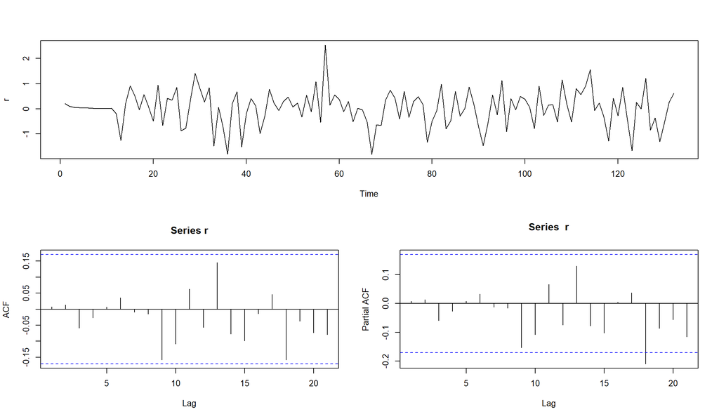

```r
> co2.fit<-Arima(co2, order=c(0,1,1), seasonal = list(order = c(0, 1, 1), period = 12))
> r<-co2.fit$res
> layout(matrix(c(1,2,1,3),2,2))
> ts.plot(r); acf(r); pacf(r)
```

```r
> Box.test(r, lag=12, type="Ljung") # 잔차의 자기상관계수가 12시차까지 0이라고 할 수 있는가?
```

```
    Box-Ljung test

data:  r
X-squared = 7.1761, df = 12, p-value = 0.8458
```

잔차 plot 및 잔차의 SACF와 SPACF, 그리고 Ljung-Box 결과 등을 살펴보면 잔차를 white noise로 간주해도 될 듯함. 잔차(모형화 후 남은 부분)에 모형화할 만한 종속관계가 더 이상 남아있지 않아 보임. 따라서, 위 잠정모형을 최종 모형으로 확정함.

#### **Cf.** 위 잔차가 $ARIMA(0,1,1)(0,1,1)_{12}$모형에서의 잔차라고 할 수 있는가? (모형의 적합도 검정)

$\Longleftrightarrow\quad \{\bigtriangledown\bigtriangledown^{12}X_t\}$가 $ARIMA(0,0,1)(0,0,1)_{12}$모형에서의 잔차라고 할 수 있는가?

```r
> Box.test(r, lag=12, type="Ljung", fitdf=1+1)
```

```
    Box-Ljung test

data:  r
X-squared = 7.1761, df = 10, p-value = 0.7087
```

p-value가 크므로 그렇다고 할 수 있음.

### 모수추정결과

```r
> co2.fit
```

```
Series: co2
ARIMA(0,1,1)(0,1,1)[12]

Coefficients:
          ma1     sma1
      -0.5792  -0.8206
s.e.   0.0791   0.1137

sigma^2 estimated as 0.5683:  log likelihood=-139.54
AIC=285.08   AICc=285.29   BIC=293.41
```

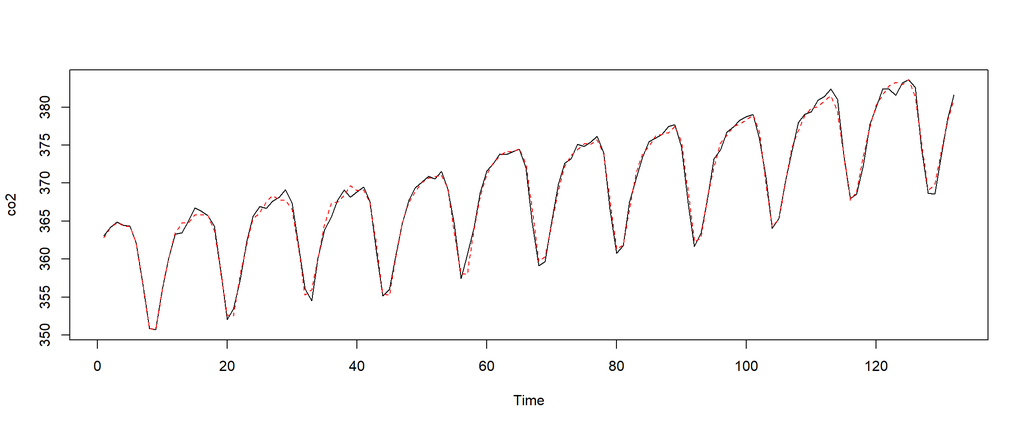

```r
> hat.co2<-co2.fit$fitted # 적합값(추정된 모형에 의해서 계산된 값)
> ts.plot(co2)
> lines(hat.co2, col="red", lty=2) # 적합값 그래프
```

### 예측

[figure not shown]

```r
> forecast(co2.fit, h=12)
```

```
    Point Forecast    Lo 80    Hi 80    Lo 95    Hi 95
133       382.8800 381.9112 383.8489 381.3983 384.3618
134       383.5533 382.5022 384.6043 381.9458 385.1607
135       383.9295 382.8022 385.0568 382.2055 385.6535
136       384.5587 383.3601 385.7574 382.7256 386.3919
137       385.0519 383.7859 386.3179 383.1157 386.9881
138       383.0727 381.7427 384.4026 381.0387 385.1066
139       376.3314 374.9405 377.7224 374.2042 378.4587
140       370.3308 368.8814 371.7802 368.1142 372.5475
141       371.0906 369.5850 372.5962 368.7880 373.3932
142       375.7499 374.1901 377.3096 373.3645 378.1353
143       380.3739 378.7618 381.9859 377.9084 382.8393
144       383.1283 381.4655 384.7910 380.5853 385.6713
```